# Getting started

# Build your models

Using scikit-learn or statsmodels, build the necessary models for your scenario. Evaluate model fit.

Use the data from 2015 to make a linear model using as many variables as you find useful to predict the yearly sales of all stores. You must use the sales from January to March as one of your variables.

```python
# There appears to be some n/a values in Q1-2015-sales. This could be due to new stores opened since Q1 2015 OR due
# to the fact we are working with 10% of the data
```

```python
# By definition given by the prompt, we want a predictive model that can predict total year sales from the first
# three month's of a year's data.
```

```python
data_2015=data2015.dropna()
```

```python
features = data_2015[["Q1-vol-sold-l","Q1-avg-ppbottle","Q1-2015-sales", "Q1-excise","2015-pop"]]
target = data_2015[["sales-pyr"]]
```

```python
import statsmodels.api as sm

X = features
y = target
X = sm.add_constant(X) ## let's add an intercept (beta_0) to our model

model = sm.OLS(y, X).fit()
predictions = model.predict(X)

# Print out the statistics
model.summary()
```

OLS Regression Results

| Dep. Variable: | sales-pyr | R-squared: | 0.983 |
| --- | --- | --- | --- |
| Model: | OLS | Adj. R-squared: | 0.983 |
| Method: | Least Squares | F-statistic: | 1.468e+04 |
| Date: | Mon, 23 Oct 2017 | Prob (F-statistic): | 0.00 |
| Time: | 07:11:35 | Log-Likelihood: | -15965. |
| No. Observations: | 1273 | AIC: | 3.194e+04 |
| Df Residuals: | 1267 | BIC: | 3.197e+04 |
| Df Model: | 5 |  |  |
| Covariance Type: | nonrobust |  |  |

|  | coef | std err | t | P>\|t\| | [0.025 | 0.975] |
| --- | --- | --- | --- | --- | --- | --- |
| const | -2.697e+04 | 7658.075 | -3.522 | 0.000 | -4.2e+04 | -1.19e+04 |
| Q1-vol-sold-l | -15.8716 | 2.810 | -5.649 | 0.000 | -21.384 | -10.359 |
| Q1-avg-ppbottle | 2974.7736 | 650.436 | 4.574 | 0.000 | 1698.724 | 4250.823 |
| Q1-2015-sales | -72.3797 | 11.799 | -6.134 | 0.000 | -95.527 | -49.232 |
| Q1-excise | 232.0787 | 35.671 | 6.506 | 0.000 | 162.099 | 302.059 |
| 2015-pop | 2.594e-05 | 4.1e-06 | 6.328 | 0.000 | 1.79e-05 | 3.4e-05 |

| Omnibus: | 788.323 | Durbin-Watson: | 1.969 |
| --- | --- | --- | --- |
| Prob(Omnibus): | 0.000 | Jarque-Bera (JB): | 117207.412 |
| Skew: | 1.856 | Prob(JB): | 0.00 |
| Kurtosis: | 49.861 | Cond. No. | 2.88e+09 |

```python
# Q1 Quantity Sold was not statistically significant (p=.76) and thus was dropped from the model
```

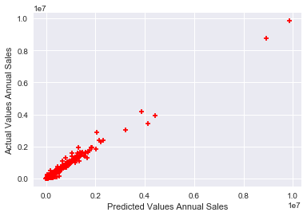

```
MSE: 6.75048467764e+13
```

```python
plt.scatter(predictions, y, s=30, c='r', marker='+', zorder=10)
plt.xlabel("Predicted Values Annual Sales")
plt.ylabel("Actual Values Annual Sales")
plt.show()
print("MSE:", model.mse_model) ## mean squared error
```

```python
# Wow, an R^2 of .983 that is uncomfortably high. We'll see how this model validates.
# MSE is pretty uninterpretable, as it seems on the line of the magnitude of most of our variables. Let's see if we
# can reduce it. I presume this is a very variant model and can be improved.
```

```python
#wow we're going to need to Regularize this data. Regularizing is a technique used to reduce over fitting.
```

```python
from sklearn.model_selection import train_test_split
X_train, X_test, y_train, y_test = train_test_split(features, target, random_state=1)
```

```python
from sklearn.linear_model import Lasso
lassoreg = Lasso(alpha=0.5, normalize=True, max_iter=10000)
lassoreg.fit(X_train, y_train)
print(lassoreg.coef_)
```

```
[ -6.41837047e+00   4.88259789e+03   4.35932363e+00   2.65599861e-01
   4.16695616e-05]
```

```python
from sklearn.linear_model import LassoCV
```

```python
# select the best alpha with LassoCV
lassoregcv = LassoCV(n_alphas=10, normalize=True, random_state=1) #n_alphas = 10 means it will generate 10 random values for alpha
lassoregcv.fit(X_train, y_train)
lassoregcv.alpha_
```

```
181.77409787129952
```

```python
from sklearn.linear_model import Lasso
lassoreg = Lasso(alpha=181.774, normalize=True)
lassoreg.fit(X_train, y_train)
print(lassoreg.coef_)
```

```
[  0.00000000e+00   3.22011861e+03   4.03002091e+00   2.99873999e-02
   3.73088093e-05]
```

```python
from sklearn import metrics
y_pred = lassoreg.predict(X_test)
print(np.sqrt(metrics.mean_squared_error(y_test, y_pred)))
print(metrics.r2_score(y_test,y_pred))
```

```
47260.2933702
0.980557382093
```

```python
#this is a better MSE, still an outrageous R^2.
```

```python
# The bias/variance trade-off:
# Based on our high R^2, and similarly high MSE, I think our model is extremely variant, meaning it is overfit
# to the training data. We've made our model slightly more bias by using Lasso Regression, but we'll see how it
# performs on 2016 data.
```

```python
data2016.columns=[["store","year","qty-sold-q1","vol-sold-l-q1","sales-q1", "excise-q1","2015-pop","2016-pop",
                   "pricepbottle-q1"]]
```

```python
feat_2016 = data2016[["vol-sold-l-q1","pricepbottle-q1","sales-q1","excise-q1","2016-pop"]].dropna()
```

```python
y_pred = lassoreg.predict(feat_2016)
```

```python
sum(y_pred)
```

```
280759663.87898874
```

According to the Iowa Division of Alcoholic Beverages Annual Report 2016: *"In Fiscal Year 2016, the Division saw another increase in liquor sales to more than $288.9 million."*  
not bad for this order of magnitude.

<font color = "red">Use your model for 2015 to estimate total sales in 2016, extrapolating from the sales so far for January to March of 2016.</font>

```python
beta_2016 = data2016[["store","vol-sold-l-q1","pricepbottle-q1","sales-q1","excise-q1","2016-pop"]].dropna(subset=["vol-sold-l-q1","pricepbottle-q1","sales-q1","excise-q1","2016-pop"])
```

```python
beta_2016["predicted-2016-sales"] = y_pred
```

```python
beta_2016=beta_2016.merge(data_2015[["store","sales-pyr","Q1-2015-sales"]], on="store", how = "left")
```

```python
beta_2016.head()
```

|  | store | vol-sold-l-q1 | pricepbottle-q1 | sales-q1 | excise-q1 | 2016-pop | predicted-2016-sales | sales-pyr | Q1-2015-sales |
| --- | --- | --- | --- | --- | --- | --- | --- | --- | --- |
| 0 | 2106 | 22277.95 | 14.310699 | 337804.05 | 112662.94 | 163339016.0 | 1.389715e+06 | 1434369.85 | 337166.53 |
| 1 | 2113 | 1608.07 | 12.763729 | 21736.63 | 7260.10 | 14450217.0 | 1.022599e+05 | 85763.42 | 22351.86 |
| 2 | 2130 | 18172.75 | 15.477121 | 306942.27 | 102365.79 | 138087256.0 | 1.267847e+06 | 1108184.99 | 277764.46 |
| 3 | 2152 | 1143.52 | 12.710018 | 13752.24 | 4604.93 | 13222490.0 | 6.978425e+04 | 72080.36 | 16805.11 |
| 4 | 2178 | 4606.64 | 12.985217 | 58939.90 | 19699.31 | 8316516.0 | 2.530472e+05 | 277987.96 | 54411.42 |

```python
beta_2016.columns=[["store","Q1-2016-vol-sold-l","Q1-2016-ppbottle", "Q1-2016-sales-pyr","Q1-2016-excise",
                    "2016-pop","predicted-2016-sales","2015-sales-pyr","Q1-2015-sales"]]
```

```python
beta_2016.head()
```

|  | store | Q1-2016-vol-sold-l | Q1-2016-ppbottle | Q1-2016-sales-pyr | Q1-2016-excise | 2016-pop | predicted-2016-sales | 2015-sales-pyr | Q1-2015-sales |
| --- | --- | --- | --- | --- | --- | --- | --- | --- | --- |
| 0 | 2106 | 22277.95 | 14.310699 | 337804.05 | 112662.94 | 163339016.0 | 1.389715e+06 | 1434369.85 | 337166.53 |
| 1 | 2113 | 1608.07 | 12.763729 | 21736.63 | 7260.10 | 14450217.0 | 1.022599e+05 | 85763.42 | 22351.86 |
| 2 | 2130 | 18172.75 | 15.477121 | 306942.27 | 102365.79 | 138087256.0 | 1.267847e+06 | 1108184.99 | 277764.46 |
| 3 | 2152 | 1143.52 | 12.710018 | 13752.24 | 4604.93 | 13222490.0 | 6.978425e+04 | 72080.36 | 16805.11 |
| 4 | 2178 | 4606.64 | 12.985217 | 58939.90 | 19699.31 | 8316516.0 | 2.530472e+05 | 277987.96 | 54411.42 |

Let's add county to our DF So we can plot sales by county later

```python
county_sales=beta_2016.merge(iowa[["store","cnty-name"]], on = "store", how="left").drop_duplicates(subset="store")
```

```python
county_sales.head()
```

|  | store | Q1-2016-vol-sold-l | Q1-2016-ppbottle | Q1-2016-sales-pyr | Q1-2016-excise | 2016-pop | predicted-2016-sales | 2015-sales-pyr | Q1-2015-sales | cnty-name |
| --- | --- | --- | --- | --- | --- | --- | --- | --- | --- | --- |
| 0 | 2106 | 22277.95 | 14.310699 | 337804.05 | 112662.94 | 163339016.0 | 1.389715e+06 | 1434369.85 | 337166.53 | Black Hawk |
| 6334 | 2113 | 1608.07 | 12.763729 | 21736.63 | 7260.10 | 14450217.0 | 1.022599e+05 | 85763.42 | 22351.86 | Webster |
| 8088 | 2130 | 18172.75 | 15.477121 | 306942.27 | 102365.79 | 138087256.0 | 1.267847e+06 | 1108184.99 | 277764.46 | Black Hawk |
| 13076 | 2152 | 1143.52 | 12.710018 | 13752.24 | 4604.93 | 13222490.0 | 6.978425e+04 | 72080.36 | 16805.11 | Cerro Gordo |
| 14818 | 2178 | 4606.64 | 12.985217 | 58939.90 | 19699.31 | 8316516.0 | 2.530472e+05 | 277987.96 | 54411.42 | Allamakee |

```python
county_sales=county_sales.groupby(["cnty-name"])["predicted-2016-sales"].sum()
```

```python
county_sales = pd.DataFrame(county_sales)
```

```python
county_sales.reset_index(inplace=True)
```

```python
county_sales
```

|  | cnty-name | predicted-2016-sales |
| --- | --- | --- |
| 0 | Adair | 3.017471e+05 |
| 1 | Adams | 1.017885e+05 |
| 2 | Allamakee | 8.096903e+05 |
| 3 | Appanoose | 7.797760e+05 |
| 4 | Audubon | 1.869861e+05 |
| 5 | Benton | 8.394049e+05 |
| 6 | Black Hawk | 1.608054e+07 |
| 7 | Boone | 1.488115e+06 |
| 8 | Bremer | 2.063157e+06 |
| 9 | Buchanan | 1.058477e+06 |
| 10 | Buena Vista | 1.704833e+06 |
| 11 | Butler | 3.708437e+05 |
| 12 | Calhoun | 4.341080e+05 |
| 13 | Carroll | 2.315461e+06 |
| 14 | Cass | 1.224245e+06 |
| 15 | Cedar | 5.839835e+05 |
| 16 | Cerro Gordo | 5.475566e+06 |
| 17 | Cherokee | 7.004633e+05 |
| 18 | Chickasaw | 4.202307e+05 |
| 19 | Clarke | 6.050323e+05 |
| 20 | Clay | 1.445532e+06 |
| 21 | Clayton | 6.869749e+05 |
| 22 | Clinton | 3.281362e+06 |
| 23 | Crawford | 1.213031e+06 |
| 24 | Dallas | 2.622205e+06 |
| 25 | Davis | 9.685968e+04 |
| 26 | Decatur | 2.428749e+05 |
| 27 | Delaware | 9.306534e+05 |
| 28 | Des Moines | 3.613035e+06 |
| 29 | Dickinson | 2.829081e+06 |
| ... | ... | ... |
| 68 | Montgomery | 6.328656e+05 |
| 69 | Muscatine | 2.998875e+06 |
| 70 | Osceola | 2.514052e+05 |
| 71 | Page | 1.215185e+06 |
| 72 | Palo Alto | 8.625692e+05 |
| 73 | Plymouth | 1.473923e+06 |
| 74 | Pocahontas | 4.146384e+05 |
| 75 | Polk | 6.552570e+07 |
| 76 | Pottawattamie | 9.969459e+06 |
| 77 | Poweshiek | 1.369151e+06 |
| 78 | Ringgold | 1.734031e+05 |
| 79 | Sac | 5.740611e+05 |
| 80 | Scott | 2.006159e+07 |
| 81 | Shelby | 7.307334e+05 |
| 82 | Sioux | 1.502713e+06 |
| 83 | Story | 9.384399e+06 |
| 84 | Tama | 7.124299e+05 |
| 85 | Taylor | 1.482449e+05 |
| 86 | Union | 1.024780e+06 |
| 87 | Van Buren | 2.250904e+05 |
| 88 | Wapello | 2.504271e+06 |
| 89 | Warren | 2.292395e+06 |
| 90 | Washington | 1.624576e+06 |
| 91 | Wayne | 1.474964e+05 |
| 92 | Webster | 3.810195e+06 |
| 93 | Winnebago | 7.386695e+05 |
| 94 | Winneshiek | 1.270644e+06 |
| 95 | Woodbury | 1.009473e+07 |
| 96 | Worth | 3.134641e+05 |
| 97 | Wright | 8.074824e+05 |

98 rows × 2 columns

# Plot your results

Again make sure that you record any valuable information. For example, in the tax scenario, did you find the sales from the first three months of the year to be a good predictor of the total sales for the year? Plot the predictions versus the true values and discuss the successes and limitations of your models

- Q1 Sales is a strong positive predictor of sales for the entire year.

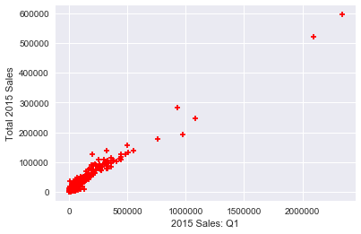

```python
plt.scatter(data_2015["Q1-2015-sales"], data_2015["qty-sold-pyr"], s=30, c='r', marker='+', zorder=10)
plt.xlabel("2015 Sales: Q1")
plt.ylabel("Total 2015 Sales")
plt.show()
```

- Model predicts actual values well

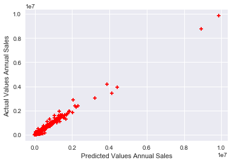

```
MSE: 6.75048467764e+13
```

```python
plt.scatter(predictions, y, s=30, c='r', marker='+', zorder=10)
plt.xlabel("Predicted Values Annual Sales")
plt.ylabel("Actual Values Annual Sales")
plt.show()
print("MSE:", model.mse_model) ## mean squared error
```

# Present the Results

Present your conclusions and results. If you have more than one interesting model feel free to include more than one along with a discussion. Use your work in this notebook to prepare your write-up.

In 2015, the following first quarter variables, by store, served as predictors in our model:

- volume sold (liters)
- avg. store price per bottle
- sales
- excise

As well as 2015 population were pretty good predictors for overall 2015 sales. While some of them were related, they indicate that a strong showing for the first three months of the year are highly indicative of liquor sale performance throughout the rest of the year. However, we also see that the model based on 2015 sales underpredictes reported 2016. This is unsurprising based on the model, as the first quarter sales of 2016 were lower than first quarter sales of 2015.  
The difference between predicted and actual values for 2016 suggests that we may have overfit the model for 2015 and should examine additional factors. Based on exploritory analysis, one particular direction of exploration that I feel has merit is to examine types of liquor stores, and training the model to better handle spikes in sales later in the year like in June and December.  
The possibility of overfitting is common in all models and is part of the bias/viarance trade off. While we can be confident first quarter sales matter, we should be cautious against considering it the only important predictor. In the case of tax legislation, it is preferrable to under predict than over predict liquor sales because it is a direct line to state revenue.

```python
county_sales.sort_values(["predicted-2016-sales"], ascending=False,inplace=True)
```

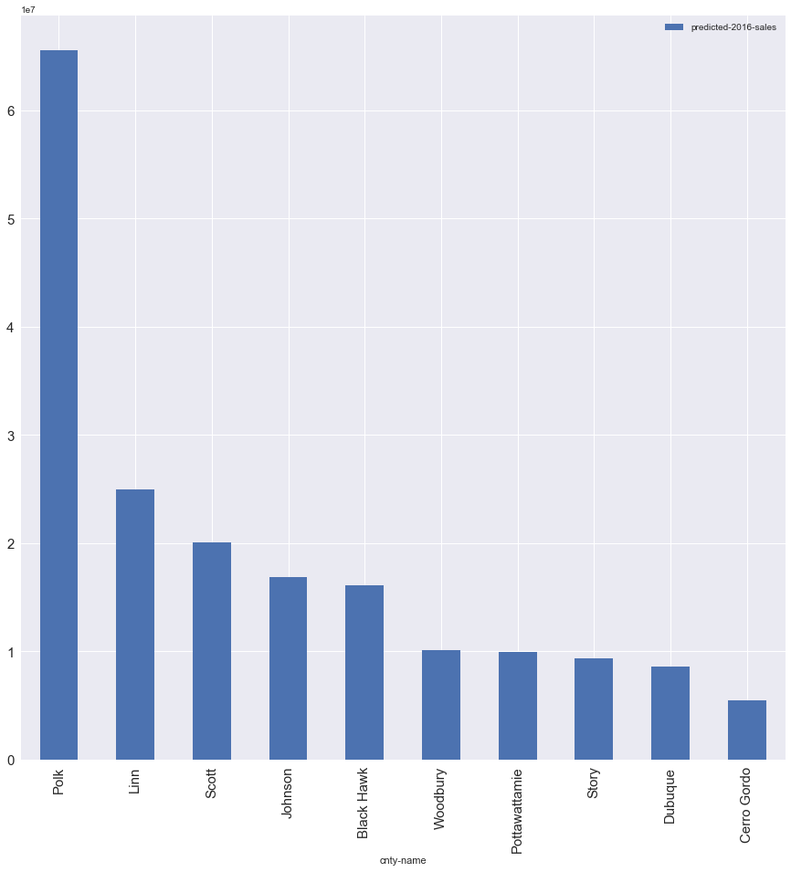

```python
county_sales[0:10].plot(x="cnty-name",y="predicted-2016-sales",kind="bar",figsize=(15,15),fontsize=15)
```